```python
from __future__ import annotations

import matplotlib.pyplot as plt
import numpy as np

from mxlpy import Model, fns, forward_sensitivities, plot
from mxlpy.runners import KineticRunner
```

# Parameter sensitivities

Global sensitivity analysis asks how much each parameter matters *across a whole range* of values. The complementary, *local* question is: **how does every simulated value change when a parameter changes a little, right here?** That is the derivative

\[S_{ij}(t) = \frac{\partial y_i(t)}{\partial \theta_j}\]

of every variable, derived quantity and reaction \(y_i\) with respect to every parameter (or initial value) \(\theta_j\). These **forward sensitivities** are what gradient-based fitting, Fisher-information analyses and identifiability checks are built on.

MxlPy computes them by solving the **sensitivity equations** alongside the model,

\[\frac{dS}{dt} = J\,S + \frac{\partial f}{\partial \theta}, \qquad S(0) = \frac{\partial x_0}{\partial \theta},\]

where both the Jacobian \(J = \partial f / \partial x\) and \(\partial f / \partial \theta\) are generated symbolically from the model. This needs a single (larger) simulation instead of one extra simulation per parameter, and is as accurate as the integrator.

## A small example

A linear chain \(x \to y \to \varnothing\) with mass-action kinetics.

```python
def get_model() -> Model:
    return (
        Model()
        .add_parameters({"k1": 0.5, "k2": 2.0})
        .add_variables({"x": 2.0, "y": 0.0})
        .add_reaction(
            "v1",
            fns.mass_action_1s,
            args=["x", "k1"],
            stoichiometry={"x": -1, "y": 1},
        )
        .add_reaction(
            "v2",
            fns.mass_action_1s,
            args=["y", "k2"],
            stoichiometry={"y": -1},
        )
    )


time_points = np.linspace(0, 10, 101)
sens = forward_sensitivities.time_course(
    get_model(), time_points, wrt=["k1", "k2", "x"]
).unwrap_or_err()
sens.derivatives["k1"].head()
```

|  | x | y | v1 | v2 |
| --- | --- | --- | --- | --- |
| 0.0 | 0.000000 | 0.000000 | 2.000000 | 0.000000 |
| 0.1 | -0.190246 | 0.172138 | 1.807336 | 0.344276 |
| 0.2 | -0.361935 | 0.296275 | 1.628707 | 0.592550 |
| 0.3 | -0.516425 | 0.382341 | 1.463204 | 0.764682 |
| 0.4 | -0.654985 | 0.438386 | 1.309969 | 0.876772 |

`forward_sensitivities.time_course` returns a `ForwardSensitivities` object with

- `simulated`: the simulated values (time × variables, derived quantities and reactions)
- `derivatives`: one DataFrame per parameter, with the same shape as `simulated`
- `method`: `"forward"` or `"finite_difference"`, see below

Variable names in `wrt` (here `x`) give the sensitivities with respect to their **initial values**.

```python
fig, axs = plot.grid_layout(3, n_cols=3, col_width=4, row_height=3)
for ax, name in zip(axs, sens.wrt, strict=True):
    plot.lines(sens.derivatives[name].loc[:, ["x", "y"]], ax=ax)
    ax.set(title=f"d / d{name}", xlabel="time")
plt.show()
```

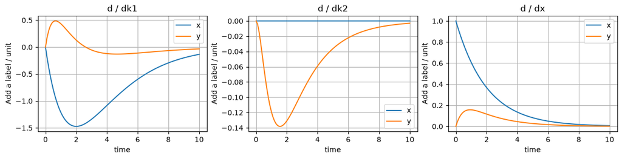

Increasing `k1` drains `x` faster (negative sensitivity of `x`) and first fills, then empties `y` faster. `k2` doesn't affect `x` at all, and a larger initial `x` scales the whole trajectory.

## Steady states

At a steady state the sensitivities follow from the implicit function theorem, \(J\,\partial x^* / \partial \theta = -\partial f / \partial \theta\), without integrating anything. Conserved quantities make \(J\) singular; their totals are then fixed by the initial values, which MxlPy takes into account.

```python
reversible = (
    Model()
    .add_parameters({"kf": 1.0, "kr": 0.5})
    .add_variables({"A": 1.0, "B": 0.0})
    .add_reaction(
        "vf", fns.mass_action_1s, args=["A", "kf"], stoichiometry={"A": -1, "B": 1}
    )
    .add_reaction(
        "vr", fns.mass_action_1s, args=["B", "kr"], stoichiometry={"A": 1, "B": -1}
    )
)
forward_sensitivities.steady_state(
    reversible, ["kf", "kr", "A"]
).unwrap_or_err().derivatives
```

```
{'kf':                A         B        vf        vr
 1000.0 -0.222222  0.222222  0.111111  0.111111,
 'kr':                A         B        vf        vr
 1000.0  0.444444 -0.444444  0.444444  0.444444,
 'A':                A         B        vf        vr
 1000.0  0.333333  0.666667  0.333333  0.333333}
```

Here \(A^* = k_r / (k_f + k_r) \cdot (A_0 + B_0)\), so e.g. \(\partial A^* / \partial k_f = -k_r (A_0 + B_0) / (k_f + k_r)^2 \approx -0.22\).

## When the model can't be differentiated symbolically

Forward sensitivities need every rate function to be convertible to sympy. Models with e.g. neural-network surrogates or functions that can't be parsed automatically fall back to **central finite differences** (two extra simulations per parameter) and log a warning. You can also choose explicitly with `method="forward"` or `method="finite_difference"`.

Finite differences are only as accurate as the integrator allows: a too small step amplifies the integration error. The default relative step `displacement=1e-3` suits the default tolerances of `1e-8`.

```python
fd = forward_sensitivities.time_course(
    get_model(), time_points, ["k1"], method="finite_difference"
).unwrap_or_err()
np.abs(fd.derivatives["k1"] - sens.derivatives["k1"]).max()
```

```
x     0.000014
y     0.000144
v1    0.000007
v2    0.000289
dtype: float64
```

The remaining differences are the error of the finite differences: for this model the forward sensitivities match the analytic solution to about \(10^{-7}\), the finite differences only to about \(10^{-4}\).

## Explicit initial values, outputs and runners

Pass explicit initial values or select only some outputs:

```
forward_sensitivities.time_course(model, time_points, ["k1"], y0={"x": 1.0, "y": 0.0}, outputs=["v1"])
```

When `y0` isn't given, the initial values are taken from the model, so initial assignments depending on the parameters are differentiated as well.

Runners provide the same with their own integrator and steady-state settings, which is where fits get their derivatives from:

```
runner = KineticRunner(derivatives="auto", displacement=1e-3)
runner.time_course_sensitivities(model, time_points, ["k1"])
runner.steady_state_sensitivities(model, ["kf"])
```

For the gradient of a loss with many parameters, adjoint gradients are much cheaper: one forward and one backward solve, whatever the number of parameters.